# Basic ggplot tutorial

Rosana Zenil-Ferguson

2023-06-28

## Open a Project

Go to File-> New Project -> New directory->New project, make sure you put it in the Desktop (so it is easy to find) and name your project “andean_tutorials”. The projects allow us to keep all our files in one place.

## Packages

Packages are groups of different functions or “actions” that allows us to do special tasks. People write packages to help others with reproducibility of analyses.

```r
install.packages("tidyr") # this works with large sets of data
install.packages("readxl") # this works with reading excel sheets
install.packages("ggplot2") # this is our superstar today we are making plots
install.packages("dplyr") # this helps us organize datasets quickly and effectively
```

It is not sufficient with installing the packages we have to load them in our “environment” (it is like bringing a pen if you are plannint to write, not only buying it!). To load them we use the function `library()`

```r
library(tidyr)
library(readxl)
library(ggplot2)
library(dplyr)
```

## Reading the data

The function `read_xlsx` allows us to read excel files. So let’s go ahead and read the dataset of the paper of Onstein et al. *Which frugivory‐related traits facilitated historical long‐distance dispersal in the custard apple family (Annonaceae)?.* Journal of Biogeography. 2019. 46(8):1874-88.

```r
onstein <- read_xlsx('~/Dropbox/AndeanWorkshop/Onstein_data.xlsx',
                     sheet = 'Matrix for analysis')

## Check what is inside the dataset, was it read fine?
head(onstein)
```

```
## # A tibble: 6 × 19
##   Species_tree          Species_PROTEUS Log_Fruit_length_avg Log_Fruit_width_avg
##   <chr>                 <chr>           <chr>                <chr>
## 1 Alphonsea_boniana_JB… Alphonsea_boni… NA                   NA
## 2 Alphonsea_elliptica_… Alphonsea_elli… 0.76342799400000005  0.57978359700000004
## 3 Alphonsea_kinabaluen… Alphonsea_kina… 0.41497334800000002  0.27875360100000002
## 4 Ambavia_gerrardii_PB  Ambavia_gerrar… 0.30102999600000002  0.113943352
## 5 Anaxagorea_javanica_… Anaxagorea_jav… 0.54406804399999997  0.54406804399999997
## 6 Anaxagorea_luzonensi… Anaxagorea_luz… 0.41497334800000002  -0.221848750000000…
## # ℹ 15 more variables: Log_Fruit_number_avg <chr>, Log_Stipe_length_avg <chr>,
## #   Log_Seed_length_avg <chr>, Log_Seed_width_avg <chr>,
## #   Log_Seed_number_avg <chr>, Log_Height_max <chr>, Bright <chr>,
## #   Pubescent <chr>, Defence <chr>, Fruit_type <chr>, Cauliflory <chr>,
## #   Moniliform <chr>, Dehiscence <chr>, Shrub <chr>, Conspicuousness <chr>
```

Now we are going to check what is in one variable called `Log_Fruit_length_avg`

```r
## Check how it was read, is it a column with numbers (aka a quantitative variable?)
head(onstein$Log_Fruit_length_avg)
```

```
## [1] "NA"                  "0.76342799400000005" "0.41497334800000002"
## [4] "0.30102999600000002" "0.54406804399999997" "0.41497334800000002"
```

```r
 #good practice, what data am I missing, what values are there?
## Make it a quantitative variable that we can work with
onstein$Log_Fruit_length_avg <- as.numeric(onstein$Log_Fruit_length_avg)
head(is.na(onstein$Log_Fruit_length_avg))
```

```
## [1]  TRUE FALSE FALSE FALSE FALSE FALSE
```

```r
## put it back in regular scale

fruit_length_average= exp(onstein$Log_Fruit_length_avg)

## Add it to your dataset- Here discuss why it is really good to "add here" instead of modifying your original data.
## Reproducibility practices
onstein<-cbind(onstein, fruit_length_average)
head(onstein)
```

```
##                   Species_tree         Species_PROTEUS Log_Fruit_length_avg
## 1       Alphonsea_boniana_JB57       Alphonsea_boniana                   NA
## 2     Alphonsea_elliptica_JB34     Alphonsea_elliptica            0.7634280
## 3 Alphonsea_kinabaluensis_JB85 Alphonsea_kinabaluensis            0.4149733
## 4         Ambavia_gerrardii_PB       Ambavia_gerrardii            0.3010300
## 5       Anaxagorea_javanica_JB     Anaxagorea_javanica            0.5440680
## 6     Anaxagorea_luzonensis_JB   Anaxagorea_luzonensis            0.4149733
##    Log_Fruit_width_avg Log_Fruit_number_avg Log_Stipe_length_avg
## 1                   NA                   NA                   NA
## 2  0.57978359700000004  0.60205999099999996  0.27875360100000002
## 3  0.27875360100000002  0.54406804399999997                    0
## 4          0.113943352  0.54406804399999997                    0
## 5  0.54406804399999997  0.90308998699999998          0.380211242
## 6 -0.22184875000000001  0.47712125500000002  0.25527250499999998
##      Log_Seed_length_avg     Log_Seed_width_avg Log_Seed_number_avg
```

[output cut: 27 more lines]

# Plotting and understanding our data

## Histograms

What are histograms? They are one of the most useful tools for **continuous traits**. They group observations in bins (or cajitas) to show us what is more frequent.

Let’s make a basic histogram!

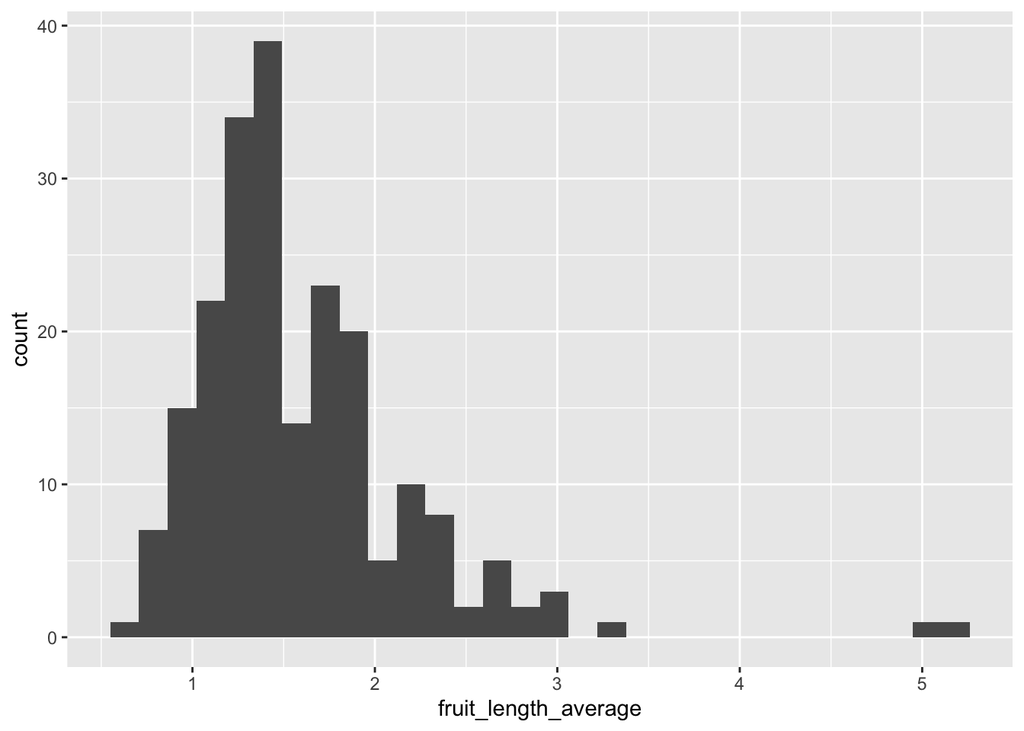

```r
ggplot(onstein, aes(x=fruit_length_average)) + geom_histogram()
```

Changing colors in and out and saving it

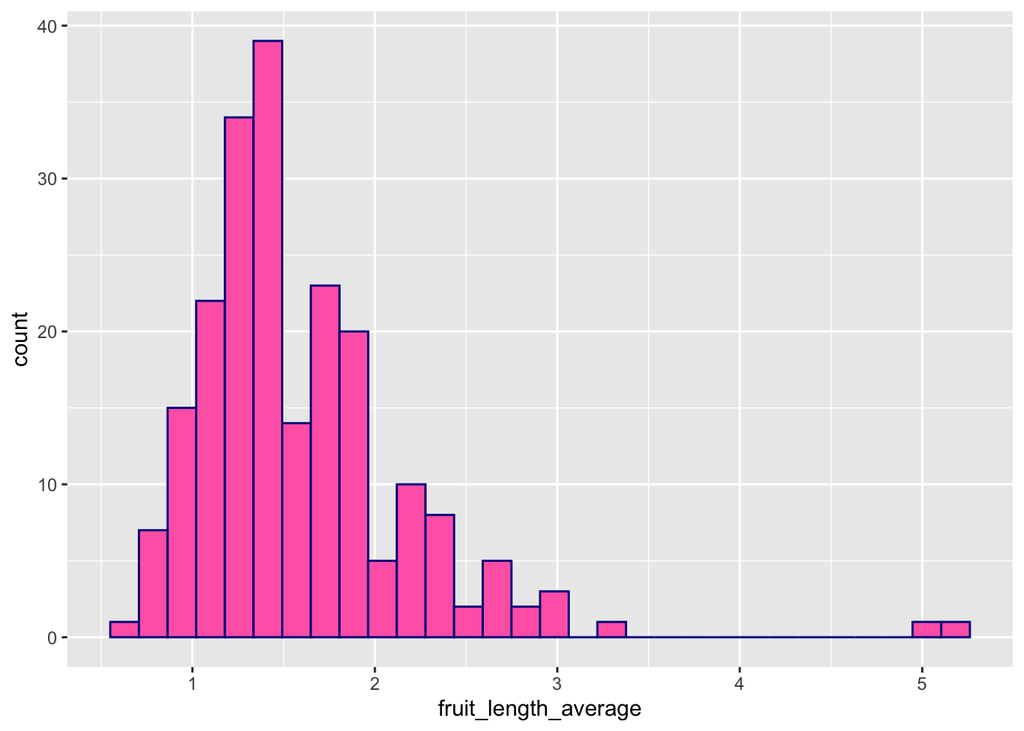

```r
p_histogram<- ggplot(onstein, aes(x=fruit_length_average))+ geom_histogram(color="darkblue", fill="hotpink")
p_histogram
```

What if we want to separate the data by the type of plant? and we have a variable `Shrub` in the dataset that tells us which one is a shrub or not a shrub

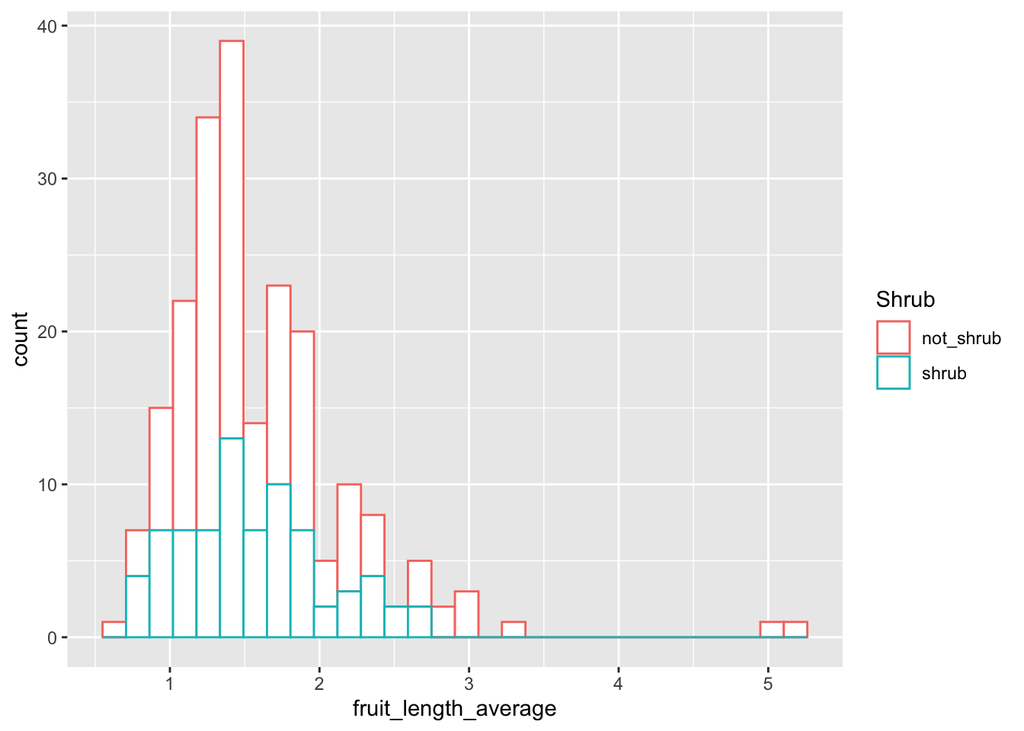

```r
p_histogram<-ggplot(onstein, aes(x=fruit_length_average, color=Shrub)) +
  geom_histogram(fill="white")
p_histogram
```

What if we want to add the mean of each group?

```r
## Calculating the mean per group using Dplyr
## we are naming the mean of each group mean_fl (as a short for mean fruit length)
mu<-onstein %>% group_by(Shrub) %>%
  summarize(mean_fl=mean(fruit_length_average, na.rm=TRUE),
            .groups = 'drop')
mu
```

```
## # A tibble: 3 × 2
##   Shrub     mean_fl
##   <chr>       <dbl>
## 1 NA         NaN
## 2 not_shrub    1.62
## 3 shrub        1.56
```

The little symbol `%>%` are called pipes in this package. Piping is an important tool for reproducibility. You never change your original data, you only reorder internally and put through a pipe line

Ok, so what is happening with the dimension of mu? what do you notice?

```r
dim(mu)
```

```
## [1] 3 2
```

```r
 ### (there are NAs this will be annoying later on, so we are going to remove)
mu<-mu[2:3,] ## discuss here how R reads tables and matrices as rows and columns!!!!
# another option mu<- mu[-1,]
```

Okay so now finally add the mean to the groups and the histogram

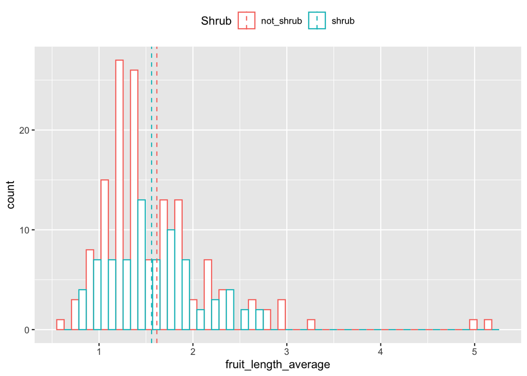

```r
p_histogram<-ggplot(onstein, aes(x=fruit_length_average, color=Shrub)) +
  geom_histogram(fill="white", position="dodge")+
  geom_vline(data=mu, aes(xintercept=mean_fl, color=Shrub),
             linetype="dashed")+
  theme(legend.position="top")
p_histogram
```

What if I want my own colors? Let’s check some cool options (aka coolors)

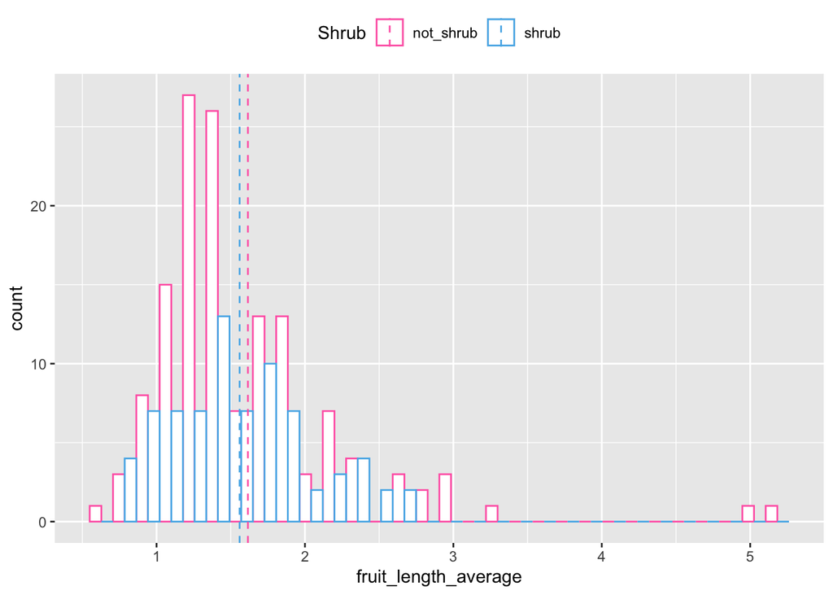

```r
p_histogram<- p_histogram+scale_color_manual(values=c("hotpink", "#56B4E9")) #EXPLAIN
p_histogram
```

But I want to make it publication quality! Let’s make nice labels on the axes and clean the background

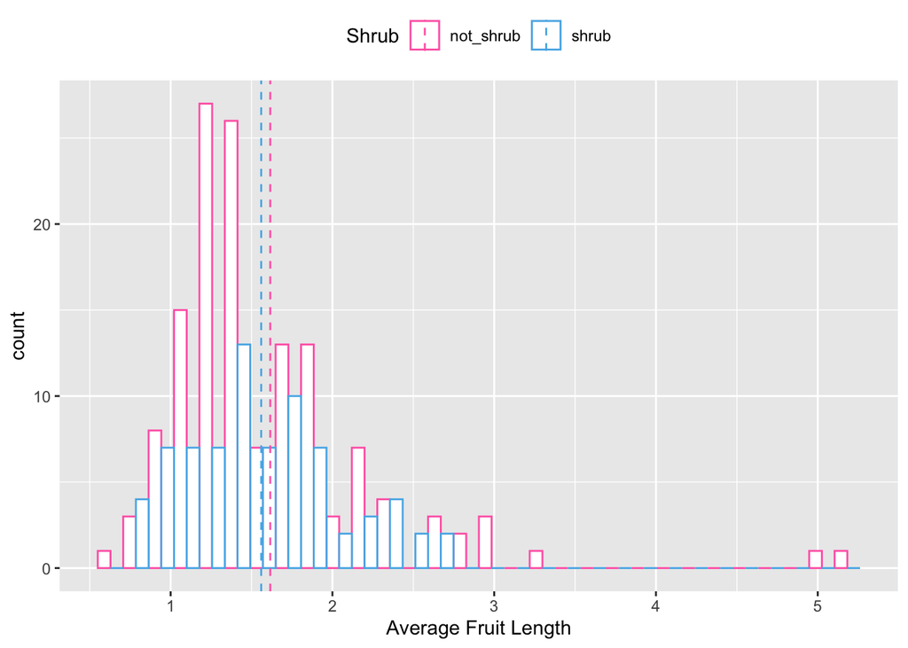

```r
p_histogram<- p_histogram+xlab("Average Fruit Length")
p_histogram
```

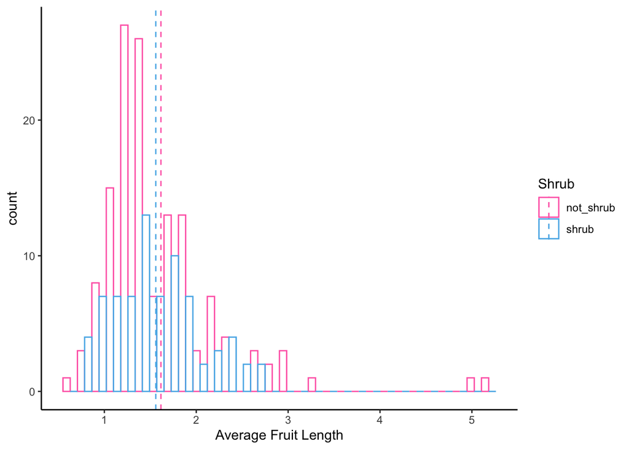

```r
p_histogram<-p_histogram+theme_classic()
p_histogram
```

## Density plots

What are density plots?- They are areas under the curve and later they will help us to decide about probability!

Let’s make a simple one!

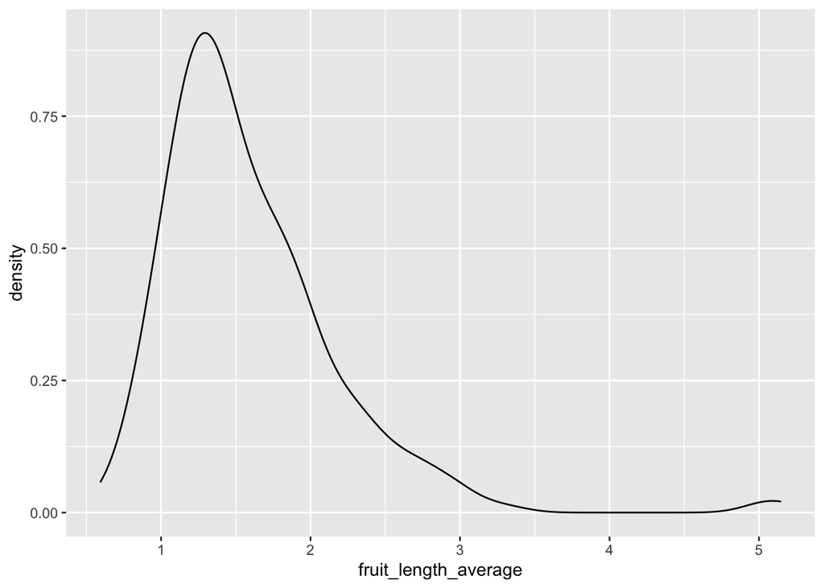

```r
p_density<-ggplot(onstein, aes(x=fruit_length_average)) + geom_density()
p_density
```

Make it pretty colors

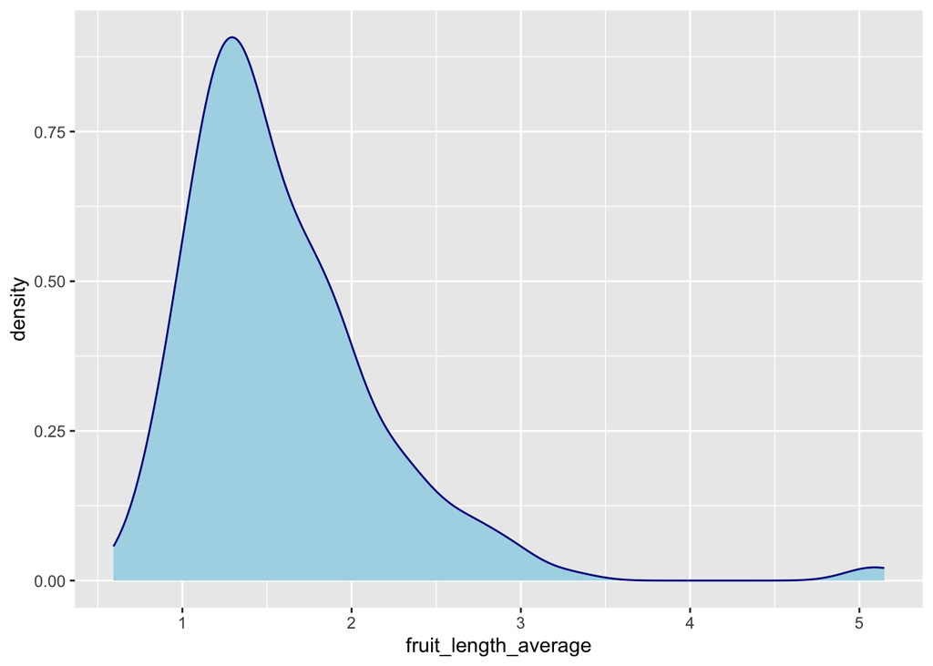

```r
p_density<-ggplot(onstein, aes(x=fruit_length_average))+
  geom_density(color="darkblue", fill="lightblue")
p_density
```

Remember those pesky `NAs` what happens in density plots if we remove them. For that we will use the function `subset()`.

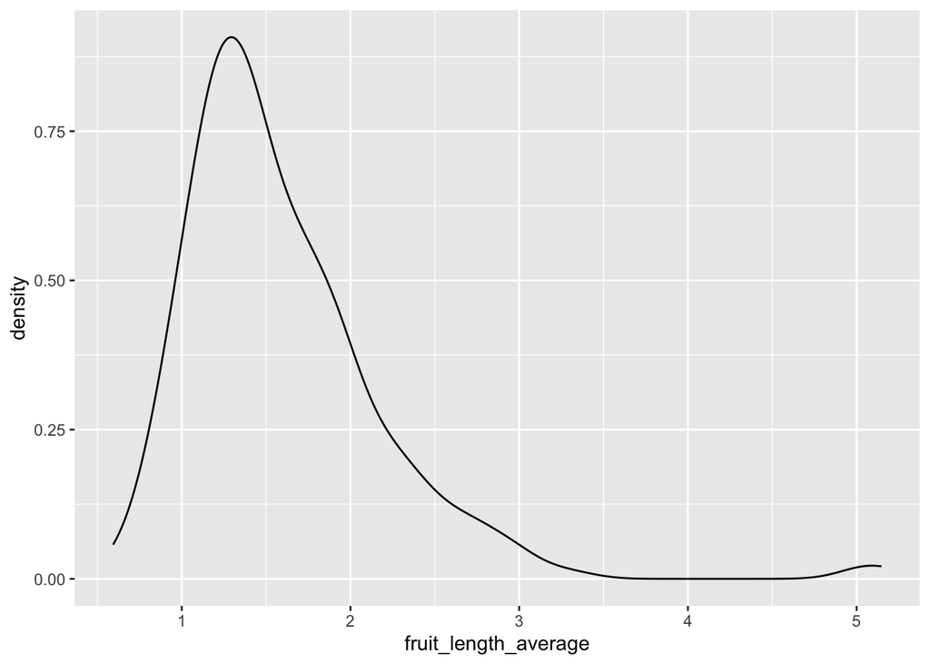

```r
p_density<-ggplot(data=subset(onstein,!is.na(fruit_length_average)), aes(x=fruit_length_average)) + geom_density()
p_density
```

We will add the mean and remember to remove `NAs` (do one with and one without NAs)

```r
mean.fruit=mean(onstein$fruit_length_average,na.rm=TRUE)
mean.fruit
```

```
## [1] 1.596013
```

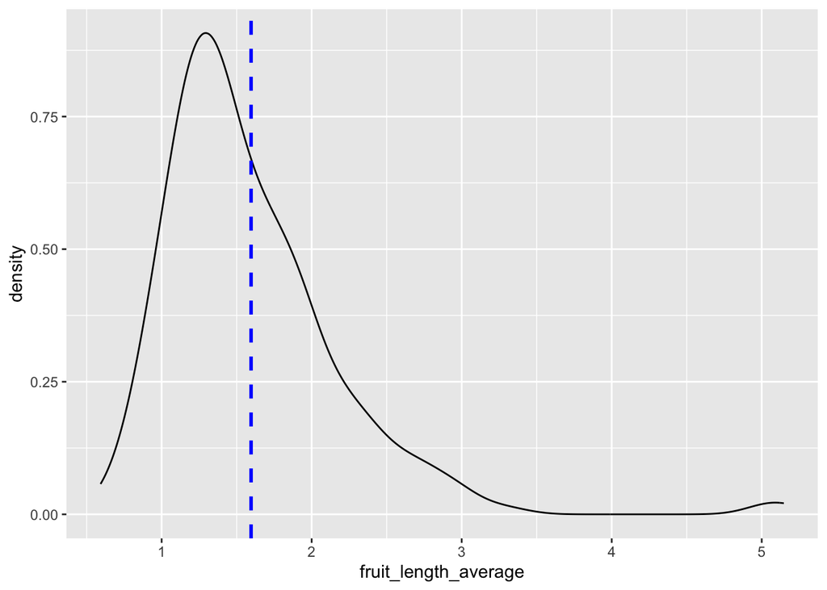

```r
p_density<-p_density+ geom_vline(aes(xintercept=mean.fruit),
              color="blue", linetype="dashed", size=1)
p_density
```

Change density plot line colors by groups

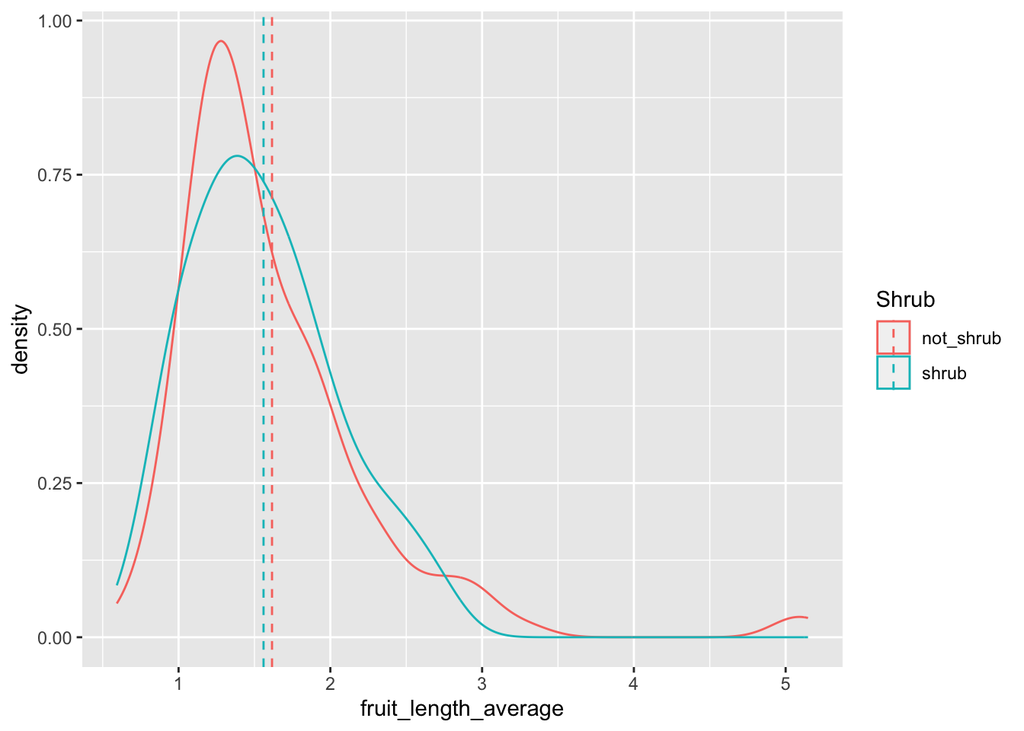

```r
p_density<-ggplot(onstein, aes(x=fruit_length_average, color=Shrub)) +
  geom_density() + geom_vline(data=mu, aes(xintercept=mean_fl, color=Shrub),
             linetype="dashed")
p_density
```

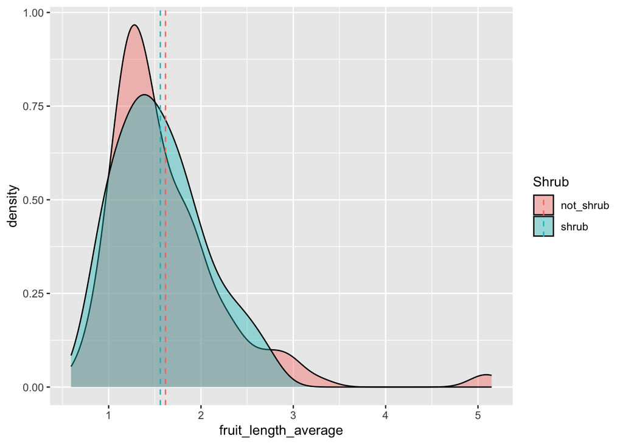

```r
# Fill them in
p_density<-ggplot(onstein, aes(x=fruit_length_average, fill=Shrub)) + geom_density(alpha=0.4)+ geom_vline(data=mu, aes(xintercept=mean_fl, color=Shrub),  linetype="dashed")
p_density
```

Adding my color scheme (tolk about coolors here)

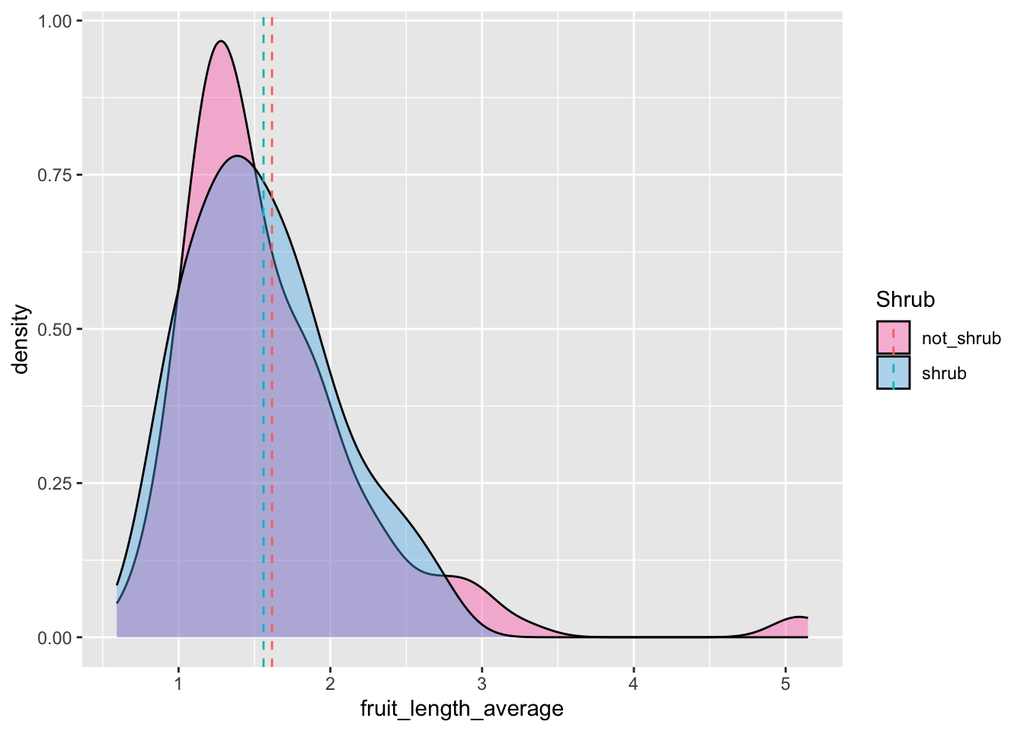

```r
p_density<-p_density+scale_fill_manual(values=c("hotpink", "#56B4E9"))
p_density
```

Making it publication style

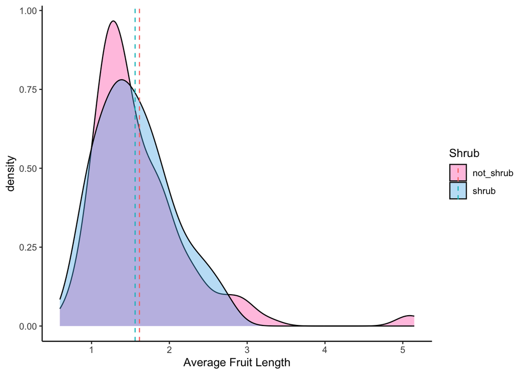

```r
p_density<- p_density+ xlab("Average Fruit Length")+theme_classic()
p_density
```

## Histogram with density plot

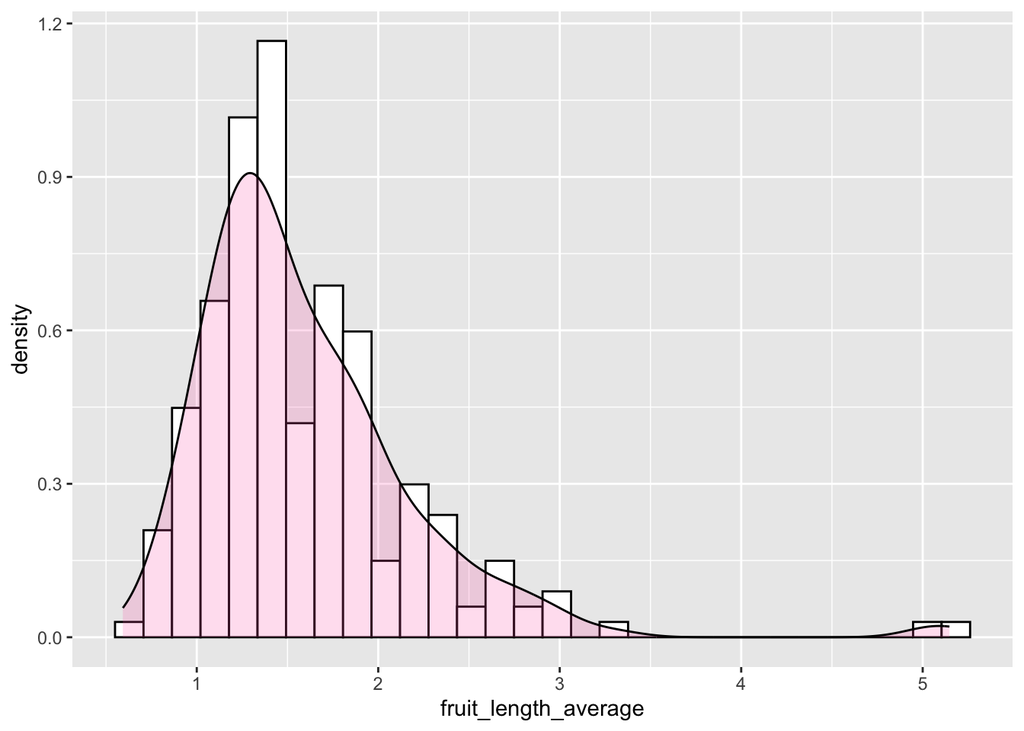

```r
p_histdensity<-ggplot(onstein, aes(x=fruit_length_average)) +
  geom_histogram(aes(y=..density..), colour="black", fill="white")+
  geom_density(alpha=.2, fill="hotpink")
p_histdensity
```

## Making Box and Whisker plots

What are box and whisker plots? What are quartiles and interquartile difference??

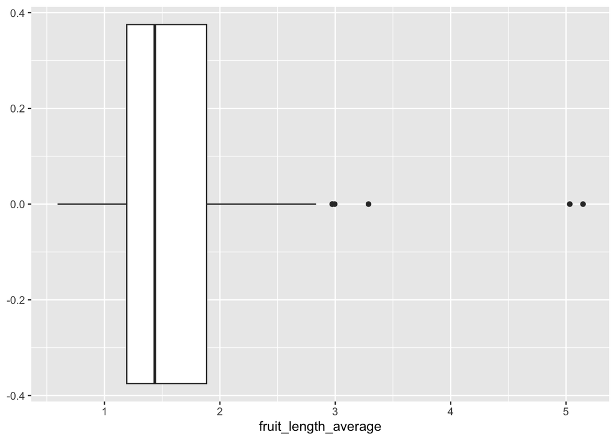

```r
ggplot(data=onstein, aes(x=fruit_length_average)) +
  geom_boxplot()
```

How do we make it vertical???

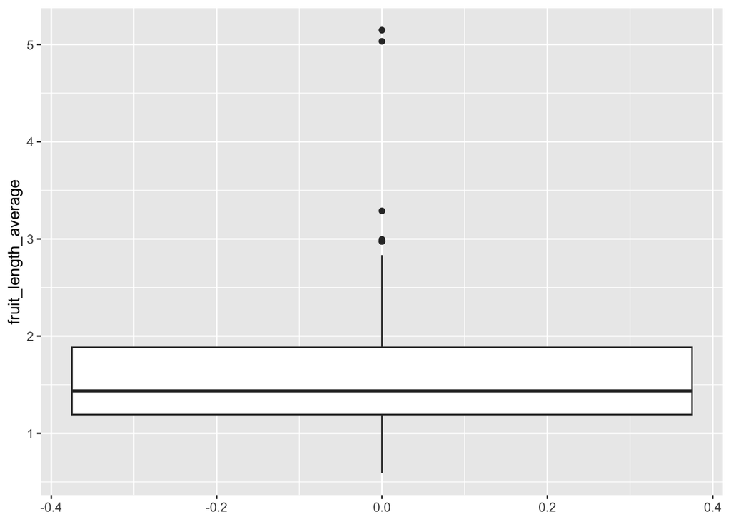

```r
p_boxplot<-ggplot(data=onstein, aes(y=fruit_length_average)) +
  geom_boxplot()
p_boxplot
```

How do we make it box and whisker plots by group??

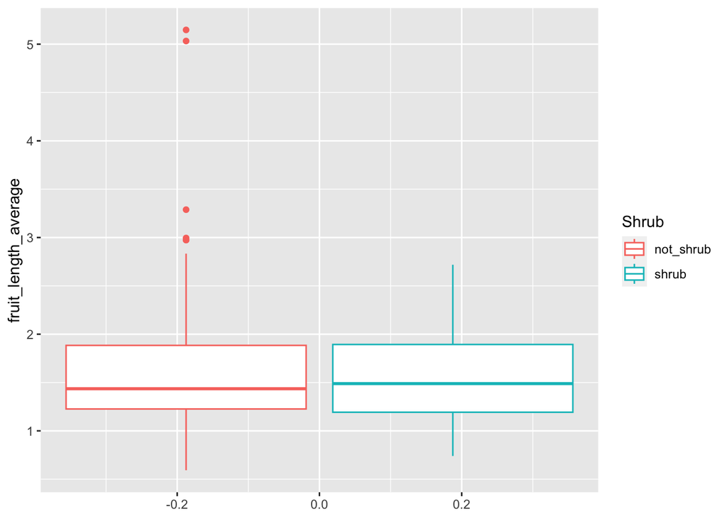

```r
p_boxplot<-ggplot(onstein, aes(y=fruit_length_average, color=Shrub)) +
  geom_boxplot()
p_boxplot
```

How do we change the color?

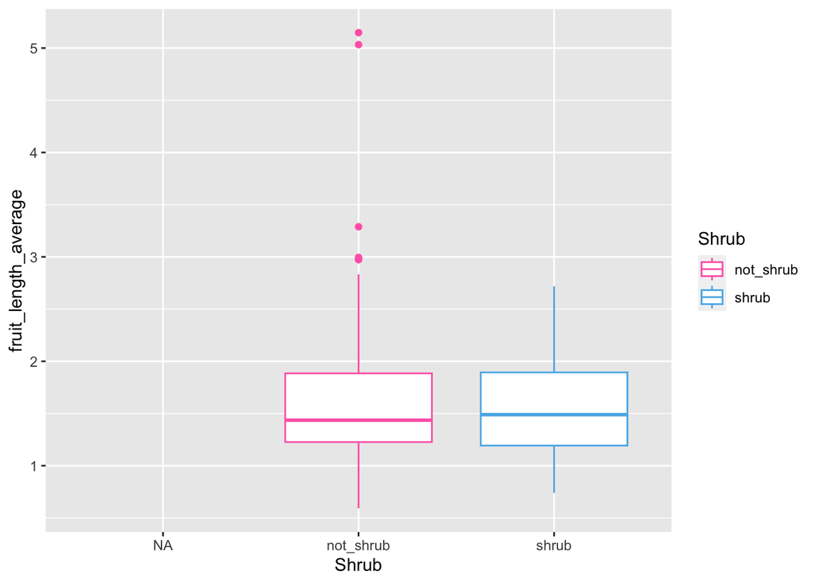

```r
p_boxplot<-ggplot(onstein, aes(x=Shrub,y=fruit_length_average, color=Shrub)) +
  geom_boxplot()+scale_color_manual(values=c("hotpink", "#56B4E9"))
p_boxplot
```

How do we fill them in

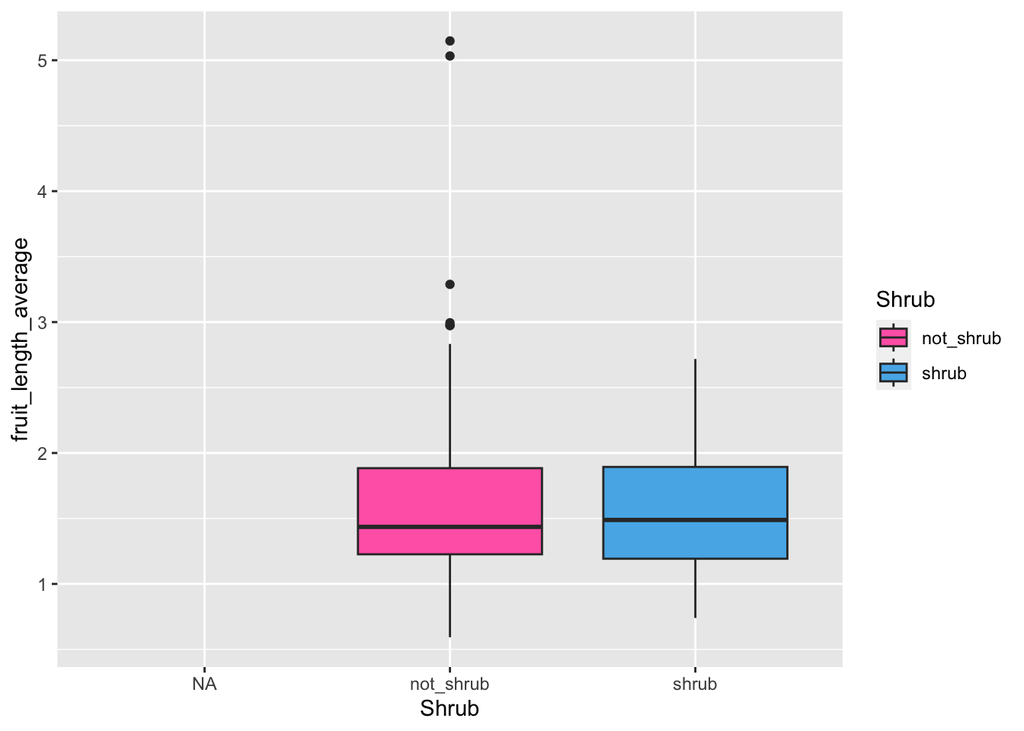

```r
p2<-ggplot(onstein, aes(x=Shrub,y=fruit_length_average, fill=Shrub)) +
  geom_boxplot()

p2+scale_fill_manual(values=c("hotpink", "#56B4E9"))
```

Eliminating those pesky NAs from plots

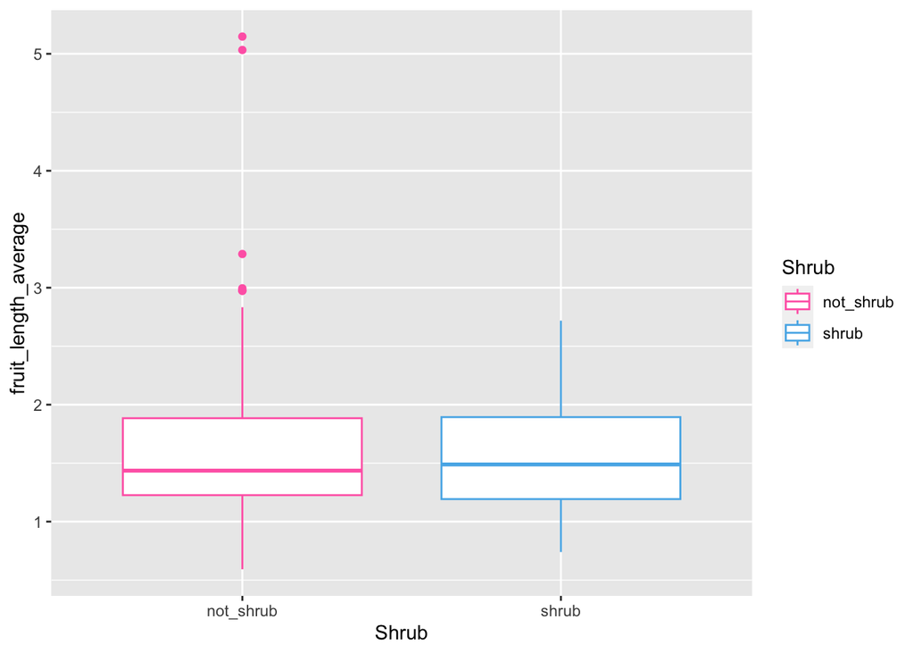

```r
p_boxplot<-ggplot(data=subset(onstein, !is.na(fruit_length_average)), aes(x=Shrub,y=fruit_length_average, color=Shrub)) +
  geom_boxplot()+scale_color_manual(values=c("hotpink", "#56B4E9"))
p_boxplot
```

How do we add the mean?

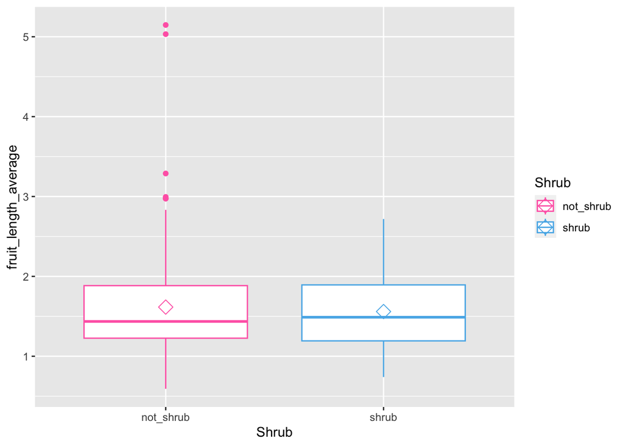

```r
p_boxplot<-p_boxplot + geom_point(data=mu,aes(x=Shrub,y=mean_fl),shape=23, size=4)
p_boxplot
```

Adding good labels

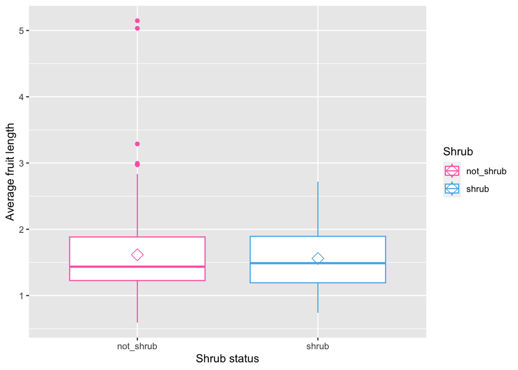

```r
p_boxplot<-p_boxplot+xlab("Shrub status")+ylab("Average fruit length")
p_boxplot
```

How do we add all the sample?

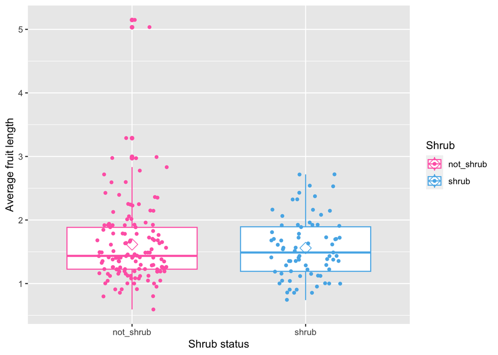

```r
p_boxplot<-p_boxplot + geom_jitter(shape=16, position=position_jitter(0.2))
p_boxplot
```

All pretty and ready for publication

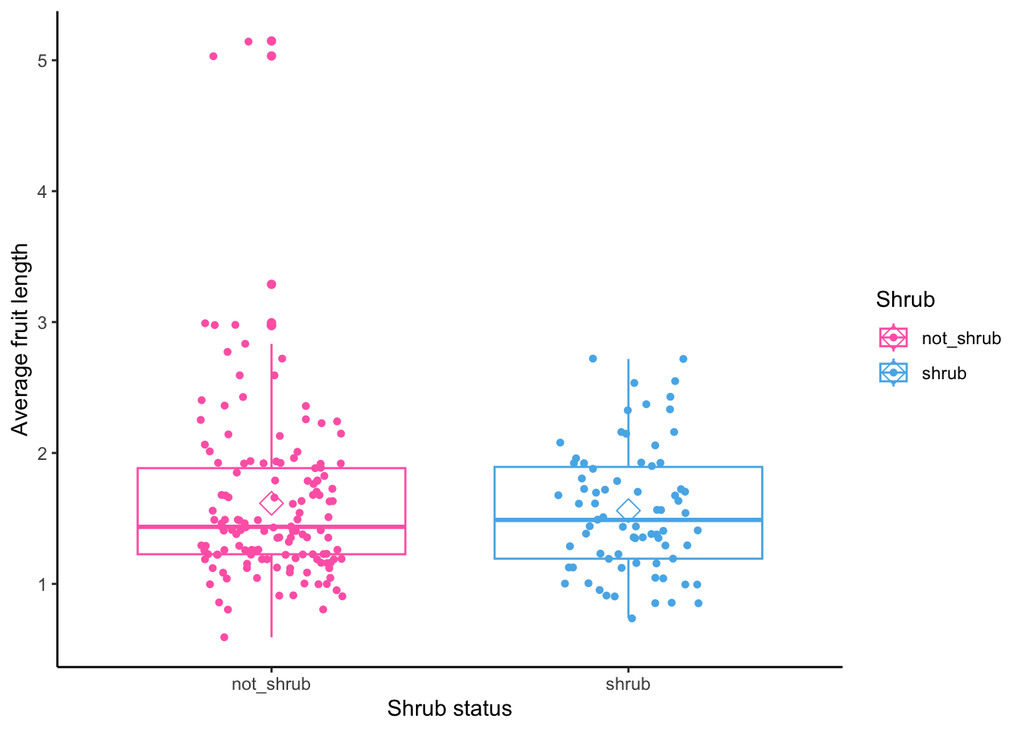

```r
p_boxplot<-p_boxplot+theme_classic()
p_boxplot
```

## Scatterplot

When do we use scatterplots? We are going to use a new variable called `Log_Fruit_width_avg` but as the other one we have to transform it

```r
head(onstein$Log_Fruit_width_avg)
```

```
## [1] "NA"                   "0.57978359700000004"  "0.27875360100000002"
## [4] "0.113943352"          "0.54406804399999997"  "-0.22184875000000001"
```

```r
onstein$Log_Fruit_width_avg <- as.numeric(onstein$Log_Fruit_width_avg)
fruit_width_average= exp(onstein$Log_Fruit_width_avg)

#add it to your dataset
onstein<-cbind(onstein, fruit_width_average)

head(onstein)
```

```
##                   Species_tree         Species_PROTEUS Log_Fruit_length_avg
## 1       Alphonsea_boniana_JB57       Alphonsea_boniana                   NA
## 2     Alphonsea_elliptica_JB34     Alphonsea_elliptica            0.7634280
## 3 Alphonsea_kinabaluensis_JB85 Alphonsea_kinabaluensis            0.4149733
## 4         Ambavia_gerrardii_PB       Ambavia_gerrardii            0.3010300
## 5       Anaxagorea_javanica_JB     Anaxagorea_javanica            0.5440680
## 6     Anaxagorea_luzonensis_JB   Anaxagorea_luzonensis            0.4149733
##   Log_Fruit_width_avg Log_Fruit_number_avg Log_Stipe_length_avg
## 1                  NA                   NA                   NA
## 2           0.5797836  0.60205999099999996  0.27875360100000002
## 3           0.2787536  0.54406804399999997                    0
## 4           0.1139434  0.54406804399999997                    0
## 5           0.5440680  0.90308998699999998          0.380211242
## 6          -0.2218488  0.47712125500000002  0.25527250499999998
##      Log_Seed_length_avg     Log_Seed_width_avg Log_Seed_number_avg
```

[output cut: 27 more lines]

Let’s make our first basic scatterplot

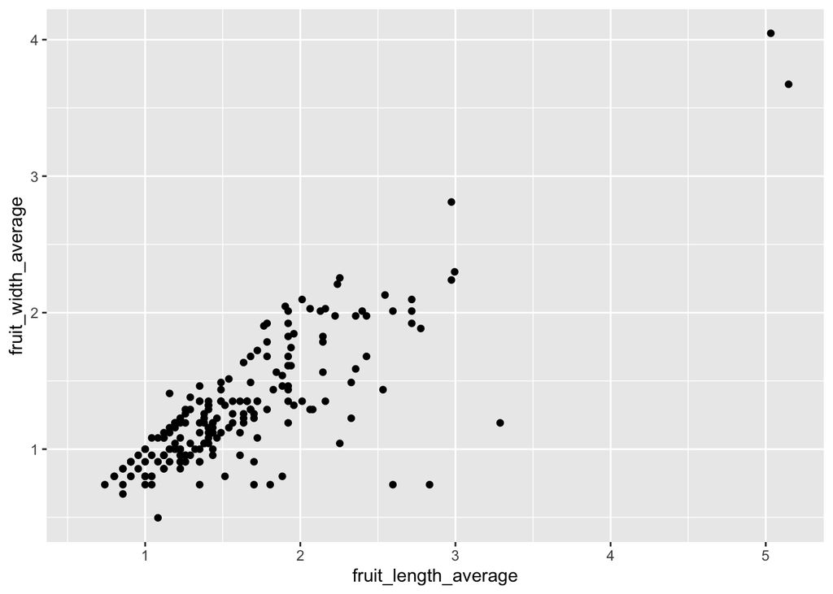

```r
ggplot(onstein, aes(x=fruit_length_average, y=fruit_width_average))+ geom_point()
```

What do we notice?

Now let’s do a regression (linear model) through it?

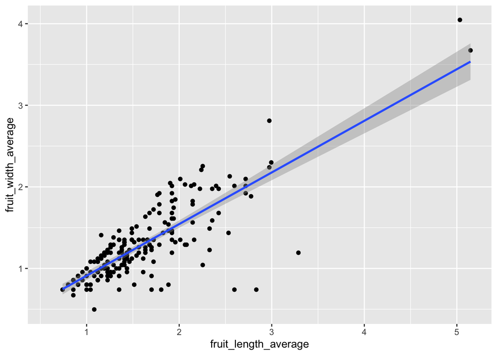

```r
p_scatter<-ggplot(onstein, aes(x=fruit_length_average, y=fruit_width_average)) +
  geom_point()+
  geom_smooth(method=lm)
p_scatter
```

Are groups different?

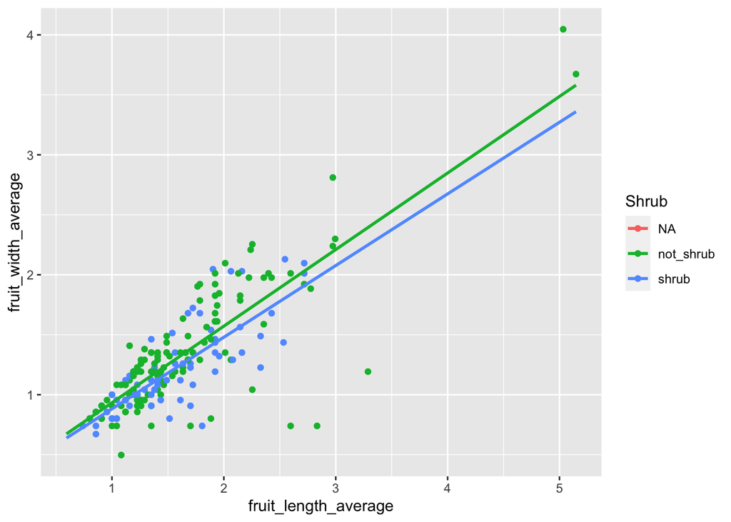

```r
p_scatter<-ggplot(onstein, aes(x=fruit_length_average, y=fruit_width_average, color=Shrub)) +geom_point() +
  geom_smooth(method=lm, se=FALSE, fullrange=TRUE)
p_scatter
```